# Aula 8 - Econometria de Séries Temporais

João Ricardo F. de Lima

30 de abril de 2022.

# 1 Modelo SARIMA

Séries econômicas com periodicidade inferior a um ano, mensais ou trimestrais, por exemplo, normalmente exibem autocorrelação importante entre as observações dos instantes do tempo distantes entre si por *s* ou múltiplos de **s**, em que o **s** é o número de períodos contidos em um ano (**s**=12 para dados mensais e igual a 4 para dados trimestrais);

Esta correlação é devido à sazonalidade que é comum em séries de preços;

A correlação sazonal precisa ser modelada e por isto surgem os modelos **ARIMA sazonais** denominados de modelos **SARIMA**.

Os modelos SARIMA incorporam, alem dos componentes AR(p), MA(q) e d diferenciações consecutivas, os componentes autoregressivo sazonal, SAR(P), média móvel sazonal, SMA(Q), e D diferenciações sazonais necessárias caso a série apresente raiz unitária sazonal;

Assim, tem-se a denominação $SARIMA(p,d,q)x(P,D,Q)_s$;

A diferenciação sazonal é dada por

$$\Delta_{12}Y_t=Y_t-Y_{t-12}=(1-L^{12})Y_t$$

em que $\Delta_{12}=(1-L^{12})$ é chamado de *operador de diferença sazonal*

No R a série com uma diferença sazonal de 12 meses é gerada com `ds12x <- diff(x, lag=12)` na qual x é a série a ser diferenciada sazonalmente.

No caso de modelos estacionários puramente sazonais que apresentam componentes sazonais autorregressivos (SAR) e de média móvel (SMA), tem-se a seguinte estrutura:

$$y_t=A_1y_{t-s}+\dots+A_Py_{t-Ps}+u_t+M_1u_{t-s}+\dots+M_Qu_{t-Qs}$$

$$y_t-A_1y_{t-s}-\dots-A_Py_{t-Ps}=u_t+M_1u_{t-s}+\dots+M_Qu_{t-Qs}$$

$$(1-A_1L^s-\dots-A_PL^{Ps})yt=(1-M_1L^S-\dots-M_QL^{Qs})u_t$$

Caso a série não seja estacionária, precisando ser diferenciada sazonalmente, o modelo sazonal autorregressivo integrado de médias móveis é dado por:

$$y_t-y_{t-s}=A_1y_{t-s}+\dots+A_Py_{t-Ps}+u_t+M_1u_{t-s}+\dots+M_Qu_{t-Qs}-y_{t-s}$$

$$\Delta_s^Dy_t=y_{t-s}(A-1)+\dots+A_Py_{t-Ps}+u_t+M_1u_{t-s}+\dots+M_Qu_{t-Qs}$$

$$(1-A_1L^s-\dots-A_PL^{Ps})\Delta_s^Dy_t=(1-M_1L^S-\dots-M_QL^{Qs})u_t$$

que pode ser escrito de forma compacta como:

$$A(L^s)\Delta_s^Dy_t=M(L^s)u_t$$

E o modelo SARIMA geral $(p,d,q)x(P,D,Q)_s$ pode ser dado por

$$\alpha(L)A(L^s)\Delta_s^D\Delta^dy_t=m(L)M(L^s)u_t$$

## 1.1 Entrada de dados no R

```r
#Direcionado o R para o Diretorio a ser trabalhado
setwd('C:/Users/Joao Ricardo Lima/Dropbox/tempecon/facape')

#Pacotes
#library(BETS)
library(urca)
#library(TSA)
library(lmtest)
library(normtest)
library(FinTS)
#library(xlsx)
library(forecast)
library(ggthemes)
library(uroot)
library(ggplot2)
library(dplyr)

#Dados
data("AirPassengers")
```

# 2 Gráficos

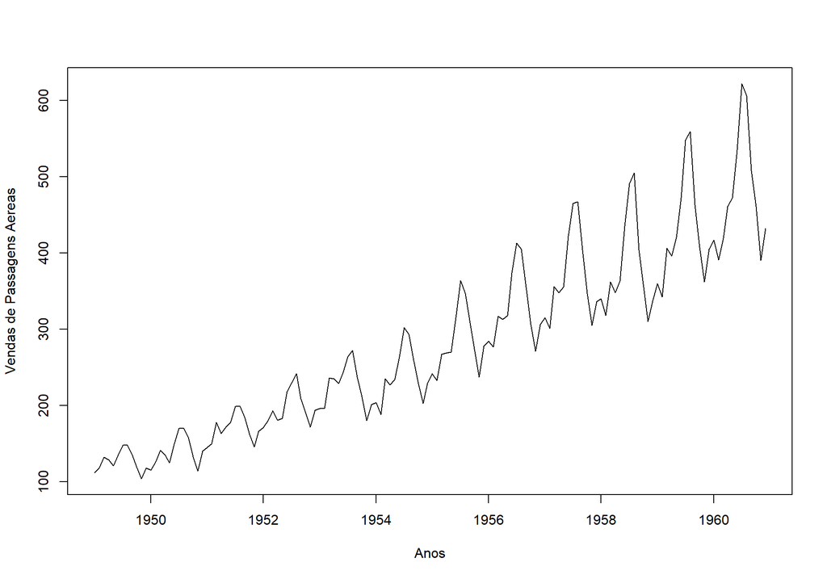

```r
ts.plot(AirPassengers, ylab="Vendas de Passagens Aereas", xlab="Anos")
```

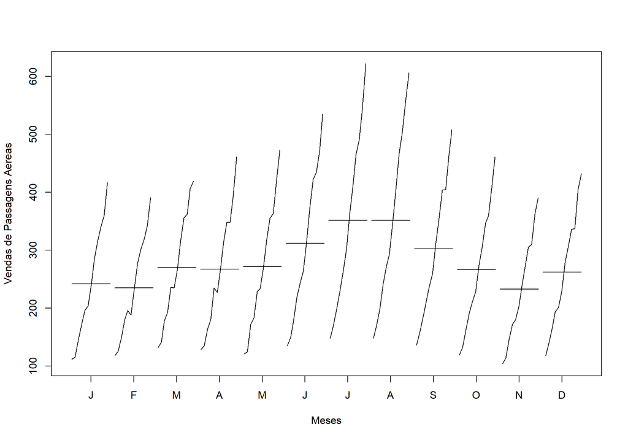

```r
monthplot(AirPassengers, ylab="Vendas de Passagens Aereas", xlab="Meses")
```

# 3 Decomposição da série

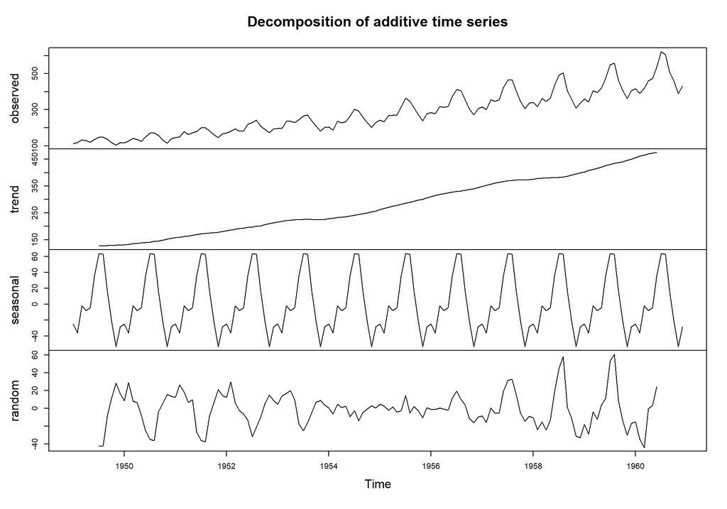

```r
plot(decompose(AirPassengers))
```

# 4 Análise de Estacionariedade da série

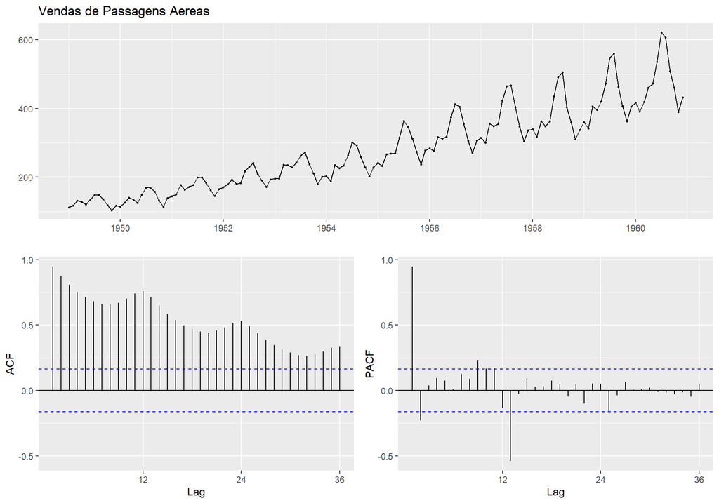

```r
#Estacionariedade da Serie
ggtsdisplay(AirPassengers, main='Vendas de Passagens Aereas')
```

```r
#Estatistica de Teste DFGLS para RPD
print(12*(length(AirPassengers)/100)^(1/4))
```

```
# [1] 13.14534
```

```r
airT.dfgls <- ur.ers(AirPassengers, type = c("DF-GLS"),
                     model = c("trend"),
                     lag.max = 13)
summary(airT.dfgls)
```

```
#
# ###############################################
# # Elliot, Rothenberg and Stock Unit Root Test #
# ###############################################
#
# Test of type DF-GLS
# detrending of series with intercept and trend
#
#
# Call:
# lm(formula = dfgls.form, data = data.dfgls)
#
# Residuals:
#     Min      1Q  Median      3Q     Max
# -30.978  -6.087  -1.210   7.082  32.427
#
# Coefficients:
#               Estimate Std. Error t value Pr(>|t|)
# yd.lag        -0.09206    0.06991  -1.317  0.19048
# yd.diff.lag1  -0.34013    0.10803  -3.148  0.00209 **
# yd.diff.lag2  -0.13102    0.10137  -1.293  0.19875
# yd.diff.lag3  -0.03303    0.10037  -0.329  0.74266
# yd.diff.lag4  -0.13435    0.09583  -1.402  0.16359
# yd.diff.lag5  -0.02399    0.09469  -0.253  0.80046
# yd.diff.lag6  -0.14632    0.08753  -1.672  0.09727 .
# yd.diff.lag7  -0.07554    0.08665  -0.872  0.38516
# yd.diff.lag8  -0.23548    0.08249  -2.855  0.00511 **
# yd.diff.lag9  -0.04678    0.08468  -0.552  0.58171
# yd.diff.lag10 -0.20776    0.07959  -2.610  0.01024 *
# yd.diff.lag11 -0.04894    0.08019  -0.610  0.54286
# yd.diff.lag12  0.81266    0.07625  10.658  < 2e-16 ***
# yd.diff.lag13  0.42608    0.09751   4.369 2.73e-05 ***
# ---
# Signif. codes:  0 '***' 0.001 '**' 0.01 '*' 0.05 '.' 0.1 ' ' 1
#
# Residual standard error: 10.8 on 116 degrees of freedom
# Multiple R-squared:  0.9155,  Adjusted R-squared:  0.9053
# F-statistic: 89.82 on 14 and 116 DF,  p-value: < 2.2e-16
#
#
# Value of test-statistic is: -1.3169
#
# Critical values of DF-GLS are:
#                  1pct  5pct 10pct
# critical values -3.46 -2.93 -2.64
```

# 5 Análise da estacionariedade da série

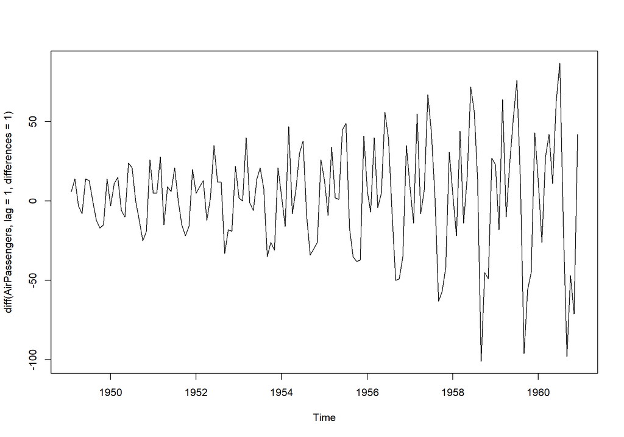

```r
#Fazendo a Primeira Diferenca da Serie

ts.plot(diff(AirPassengers, lag=1, differences = 1))
```

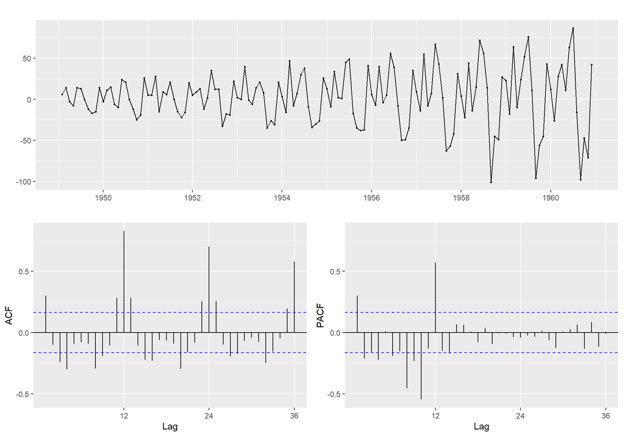

```r
ggtsdisplay(diff(AirPassengers, lag=1, differences = 1))
```

```r
# Teste de raiz unitária

dair <- diff(AirPassengers, lag=1, differences = 1)

dairT.dfgls <- ur.ers(dair, type = c("DF-GLS"),
                     model = c("constant"),
                     lag.max = 12)
summary(dairT.dfgls)
```

```
#
# ###############################################
# # Elliot, Rothenberg and Stock Unit Root Test #
# ###############################################
#
# Test of type DF-GLS
# detrending of series with intercept
#
#
# Call:
# lm(formula = dfgls.form, data = data.dfgls)
#
# Residuals:
#     Min      1Q  Median      3Q     Max
# -31.532  -7.063  -2.453   6.258  27.800
#
# Coefficients:
#               Estimate Std. Error t value Pr(>|t|)
# yd.lag        -0.31136    0.25217  -1.235    0.219
# yd.diff.lag1  -1.04442    0.25351  -4.120 7.11e-05 ***
# yd.diff.lag2  -1.14821    0.23739  -4.837 4.06e-06 ***
# yd.diff.lag3  -1.13534    0.21798  -5.208 8.27e-07 ***
# yd.diff.lag4  -1.22652    0.20159  -6.084 1.52e-08 ***
# yd.diff.lag5  -1.19061    0.18190  -6.545 1.65e-09 ***
# yd.diff.lag6  -1.27589    0.16664  -7.656 6.02e-12 ***
# yd.diff.lag7  -1.27335    0.14919  -8.535 5.90e-14 ***
# yd.diff.lag8  -1.43049    0.13617 -10.505  < 2e-16 ***
# yd.diff.lag9  -1.37460    0.12210 -11.258  < 2e-16 ***
# yd.diff.lag10 -1.47979    0.10909 -13.564  < 2e-16 ***
# yd.diff.lag11 -1.41081    0.10054 -14.032  < 2e-16 ***
# yd.diff.lag12 -0.48323    0.09306  -5.193 8.86e-07 ***
# ---
# Signif. codes:  0 '***' 0.001 '**' 0.01 '*' 0.05 '.' 0.1 ' ' 1
#
# Residual standard error: 11.1 on 117 degrees of freedom
# Multiple R-squared:  0.9349,  Adjusted R-squared:  0.9276
# F-statistic: 129.2 on 13 and 117 DF,  p-value: < 2.2e-16
#
#
# Value of test-statistic is: -1.2347
#
# Critical values of DF-GLS are:
#                  1pct  5pct 10pct
# critical values -2.58 -1.94 -1.62
```

# 6 Tornando a série estacionária

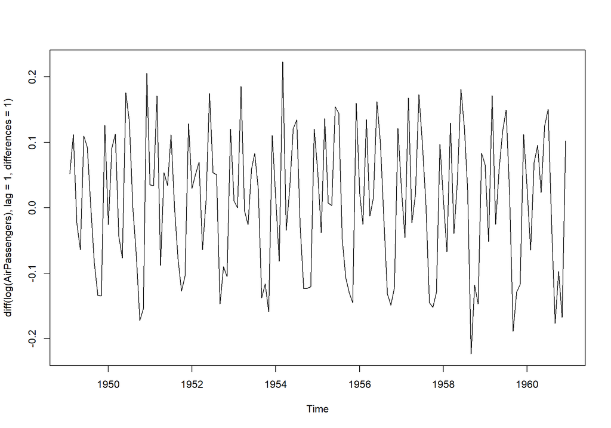

```r
#Gráfico da Primeira Diferenca da Serie em LOG

ts.plot(diff(log(AirPassengers), lag=1, differences = 1))
```

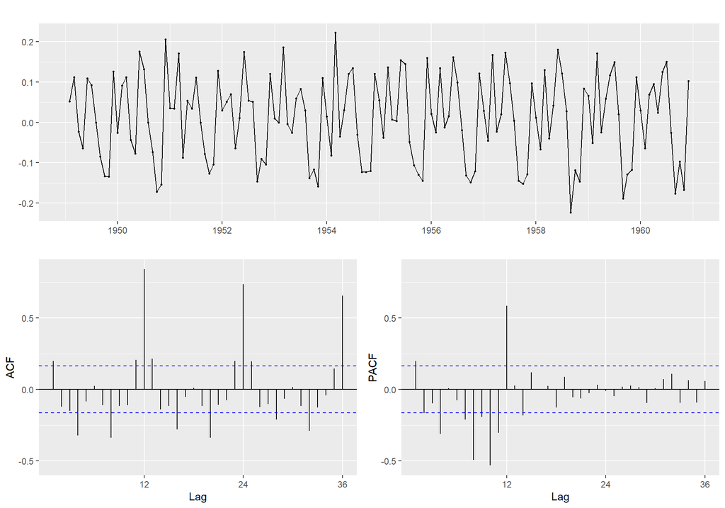

```r
# Correlogramas da série
ggtsdisplay(diff(log(AirPassengers), lag=1, differences = 1))
```

```r
# Geração da série em log diferenciada

dlair <- diff(log(AirPassengers), lag=1, differences = 1)

# Teste de raiz unitária da série em log diferenciada
dlairT.dfgls <- ur.ers(dlair, type = c("DF-GLS"),
                      model = c("constant"),
                      lag.max = 12)
summary(dlairT.dfgls)
```

```
#
# ###############################################
# # Elliot, Rothenberg and Stock Unit Root Test #
# ###############################################
#
# Test of type DF-GLS
# detrending of series with intercept
#
#
# Call:
# lm(formula = dfgls.form, data = data.dfgls)
#
# Residuals:
#       Min        1Q    Median        3Q       Max
# -0.107033 -0.026273 -0.006601  0.026357  0.109519
#
# Coefficients:
#               Estimate Std. Error t value Pr(>|t|)
# yd.lag        -0.05058    0.11170  -0.453    0.652
# yd.diff.lag1  -1.23827    0.13542  -9.144 2.25e-15 ***
# yd.diff.lag2  -1.29527    0.13243  -9.781  < 2e-16 ***
# yd.diff.lag3  -1.26271    0.12651  -9.981  < 2e-16 ***
# yd.diff.lag4  -1.32417    0.12193 -10.860  < 2e-16 ***
# yd.diff.lag5  -1.25007    0.11597 -10.780  < 2e-16 ***
# yd.diff.lag6  -1.28238    0.11190 -11.460  < 2e-16 ***
# yd.diff.lag7  -1.27123    0.10818 -11.751  < 2e-16 ***
# yd.diff.lag8  -1.37177    0.10392 -13.200  < 2e-16 ***
# yd.diff.lag9  -1.29741    0.10076 -12.877  < 2e-16 ***
# yd.diff.lag10 -1.33636    0.09598 -13.923  < 2e-16 ***
# yd.diff.lag11 -1.25533    0.09243 -13.582  < 2e-16 ***
# yd.diff.lag12 -0.39917    0.08518  -4.686 7.58e-06 ***
# ---
# Signif. codes:  0 '***' 0.001 '**' 0.01 '*' 0.05 '.' 0.1 ' ' 1
#
# Residual standard error: 0.04234 on 117 degrees of freedom
# Multiple R-squared:  0.9124,  Adjusted R-squared:  0.9026
# F-statistic: 93.69 on 13 and 117 DF,  p-value: < 2.2e-16
#
#
# Value of test-statistic is: -0.4528
#
# Critical values of DF-GLS are:
#                  1pct  5pct 10pct
# critical values -2.58 -1.94 -1.62
```

# 7 Teste de Raiz Unitária Sazonal

Em um grande número de séries temporais econômicas mensais e trimestrais, o componente sazonal está presente, fazendo com que a série apresente picos ou vales em períodos de tempo determinados.

Quando existem indícios de sazonalidade estocástica, utilizam-se testes de raízes unitárias sazonais. A partir de tais testes, é possível analisar a estacionariedade de uma série temporal na presença de componentes sazonais e, conseqüentemente, definir a ordem de integração da mesma.

O teste mais conhecido de raízes sazonais foi o previsto por Hyllerberg et al (1990), chamado de teste HEGY.

No caso de séries trimestrais, para checar se existe raiz unitária sazonal é estimado o modelo:

$$\Delta_4y_t=\pi_1z_{1,t-1}+\pi_2z_{2,t-1}+\pi_3z_{3,t-1}+\pi_4z_{3,t-2}+\sum_{j=1}^{p}\alpha_j^*\Delta_4y_{t-j}+u_t$$

em que $z_{1t}=(1+L+L^2+L^3)y_t$, $z_{2t}=-(1-L+L^2+L^3)y_t$ e $z_{3t}=-(1-L^2)y_t$ com L sendo o operado de defasagem.

A hipótese nula de que $H_0:\pi_1=0$, $H_0:\pi_2=0$ e $H_0:\pi_3=\pi_4=0$, corresponde aos testes de raizes regulares, semestrais e anuais, respectivamente.

O modelo acima é estimado por MQO e se faz testes t para significâncias individuais e F para testar hipóteses conjuntas.

No caso de séries mensais, para checar se existe raiz unitária sazonal é estimado o modelo:

$$\begin{align*}
\Delta_{12}y_t=\pi_1z_{1,t-1}+\pi_2z_{2,t-1}+\pi_3z_{3,t-1}+\pi_4z_{3,t-2}+\pi_5z_{4,t-1}+
\\
\pi_6z_{4,t-2}+\pi_7z_{5,t-1}+\pi_8z_{5,t-2}+\pi_9z_{6,t-1}+\pi_{10}z_{6,t-2}+
\\
\pi_{11}z_{7,t-1}+\pi_{12}z_{7,t-2}+\sum_{j=1}^{p}\alpha_j^*\Delta_{12}y_{t-j}+u_t
\end{align*}$$

O processo tem uma raiz unitaria regular se $\pi=0$ e tem raiz unitária sazonal se qualquer outro $\pi_i$ (i=2,…,12) for zero;

No caso de raízes mensais, as significâncias das frequências indicam o ciclo sazonal.

| **Freq.** | **$0$** | **$\pi$** | **$\frac{\pi}{2}$** | **$\frac{2\pi}{3}$** | **$\frac{\pi}{3}$** | **$\frac{5\pi}{6}$** | **$\frac{\pi}{6}$** |
| --- | --- | --- | --- | --- | --- | --- | --- |
| Coef | $\pi_1$ | $\pi_2$ | $\pi_3$ $\pi_4$ | $\pi_5$ $\pi_6$ | $\pi_7$ $\pi_8$ | $\pi_9$ $\pi_{10}$ | $\pi_{11}$ $\pi_{12}$ |
| Período | $\infty$ | 2 | 4 | 3 | 6 | 2.4 | 12 |
| Ciclo | $0$ | 6 | 3 | 4 | 2 | 5 | 1 |

Assim a frequência zero corresponde a zero ciclos sazonais, ou seja, uma raiz unitária regular. Na frequência $\pi$ se tem 6 ciclos sazonais de 2 períodos (meses) e assim sucessivamente, até a frequência $\pi/6$ que corresponde a um ciclo sazonal de 12 meses.

```r
#Teste de Raiz Unitária Sazonal HEGY
hegy.test(log(AirPassengers), deterministic = c(1,1,1),
          lag.method = "AICc")
```

[output not shown]

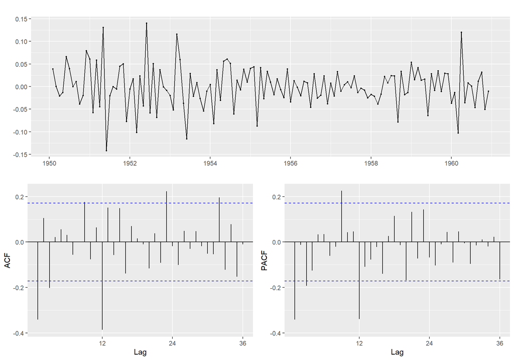

```r
#Fazendo a diferenciacao Sazonal
ggtsdisplay(diff(diff(log(AirPassengers), lag=1, differences = 1), lag=12, differences = 1))
```

```r
ds12lair <- diff(diff(log(AirPassengers), lag=1, differences = 1), lag=12, differences = 1)

#Teste de Raiz Unitária Sazonal HEGY
hegy.test(ds12lair, deterministic = c(1,1,1),
          lag.method = "AICc")
```

[output not shown]

# 8 Estimação do Modelo SARIMA

```r
auto.arima <- auto.arima(log(AirPassengers), max.p=6, max.d=1, max.q=6, max.P=6, max.Q=6,  max.D=1, seasonal = T, trace = TRUE)
```

```
#
#  ARIMA(2,1,2)(1,1,1)[12]                    : Inf
#  ARIMA(0,1,0)(0,1,0)[12]                    : -434.799
#  ARIMA(1,1,0)(1,1,0)[12]                    : -474.6299
#  ARIMA(0,1,1)(0,1,1)[12]                    : -483.2101
#  ARIMA(0,1,1)(0,1,0)[12]                    : -449.8857
#  ARIMA(0,1,1)(1,1,1)[12]                    : -481.5957
#  ARIMA(0,1,1)(0,1,2)[12]                    : -481.6451
#  ARIMA(0,1,1)(1,1,0)[12]                    : -477.2164
#  ARIMA(0,1,1)(1,1,2)[12]                    : Inf
#  ARIMA(0,1,0)(0,1,1)[12]                    : -467.4644
#  ARIMA(1,1,1)(0,1,1)[12]                    : -481.582
#  ARIMA(0,1,2)(0,1,1)[12]                    : -481.2991
#  ARIMA(1,1,0)(0,1,1)[12]                    : -481.3006
#  ARIMA(1,1,2)(0,1,1)[12]                    : -481.5633
#
#  Best model: ARIMA(0,1,1)(0,1,1)[12]
```

```r
summary(auto.arima)
```

```
# Series: log(AirPassengers)
# ARIMA(0,1,1)(0,1,1)[12]
#
# Coefficients:
#           ma1     sma1
#       -0.4018  -0.5569
# s.e.   0.0896   0.0731
#
# sigma^2 = 0.001371:  log likelihood = 244.7
# AIC=-483.4   AICc=-483.21   BIC=-474.77
#
# Training set error measures:
#                        ME       RMSE        MAE        MPE      MAPE      MASE
# Training set 0.0005730622 0.03504883 0.02626034 0.01098898 0.4752815 0.2169522
#                    ACF1
# Training set 0.01443892
```

```r
coeftest(auto.arima)
```

```
#
# z test of coefficients:
#
#       Estimate Std. Error z value  Pr(>|z|)
# ma1  -0.401828   0.089644 -4.4825 7.378e-06 ***
# sma1 -0.556945   0.073100 -7.6190 2.557e-14 ***
# ---
# Signif. codes:  0 '***' 0.001 '**' 0.01 '*' 0.05 '.' 0.1 ' ' 1
```

# 9 Verificação dos pressupostos do Modelo SARIMA

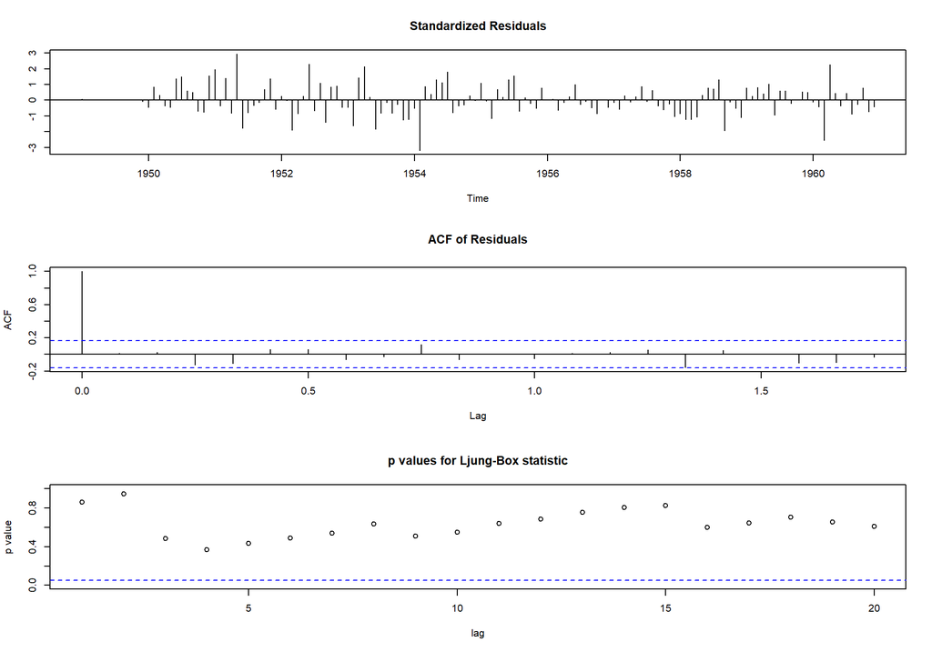

```r
#Etapa da Verificacao
diag<-tsdiag(auto.arima, gof.lag=20)
```

```r
#Teste de nao existencia de autocorrelacao serial
Box.test(x=auto.arima$residuals, lag=24, type="Ljung-Box",
         fitdf=2)
```

```
#
#   Box-Ljung test
#
# data:  auto.arima$residuals
# X-squared = 26.446, df = 22, p-value = 0.233
```

```r
#Teste de Homocedasticidade
ArchTest(auto.arima$residuals, lags=12)
```

```
#
#   ARCH LM-test; Null hypothesis: no ARCH effects
#
# data:  auto.arima$residuals
# Chi-squared = 14.859, df = 12, p-value = 0.2493
```

```r
#Normalidade dos residuos
jb.norm.test(auto.arima$residuals, nrepl=2000)
```

```
#
#   Jarque-Bera test for normality
#
# data:  auto.arima$residuals
# JB = 5.2265, p-value = 0.058
```

# 10 Previsao

```r
forecast.sarima <- forecast(auto.arima, h=12, level=c(20, 40, 60)) #level e o intervalo de confianca da previsao
forecast.sarima
```

```
#          Point Forecast    Lo 20    Hi 20    Lo 40    Hi 40    Lo 60    Hi 60
# Jan 1961       6.110186 6.100804 6.119567 6.090767 6.129605 6.079020 6.141351
# Feb 1961       6.053775 6.042843 6.064707 6.031147 6.076403 6.017459 6.090091
# Mar 1961       6.171715 6.159427 6.184003 6.146280 6.197150 6.130894 6.212536
# Apr 1961       6.199300 6.185792 6.212809 6.171338 6.227262 6.154424 6.244177
# May 1961       6.232556 6.217928 6.247184 6.202277 6.262835 6.183961 6.281151
# Jun 1961       6.368779 6.353111 6.384446 6.336348 6.401209 6.316731 6.420827
# Jul 1961       6.507294 6.490651 6.523936 6.472846 6.541742 6.452008 6.562580
# Aug 1961       6.502906 6.485343 6.520469 6.466553 6.539260 6.444562 6.561251
# Sep 1961       6.324698 6.306260 6.343136 6.286534 6.362862 6.263448 6.385949
# Oct 1961       6.209008 6.189735 6.228281 6.169115 6.248901 6.144983 6.273033
# Nov 1961       6.063487 6.043414 6.083561 6.021938 6.105037 5.996804 6.130171
# Dec 1961       6.168025 6.147182 6.188868 6.124882 6.211168 6.098784 6.237265
```

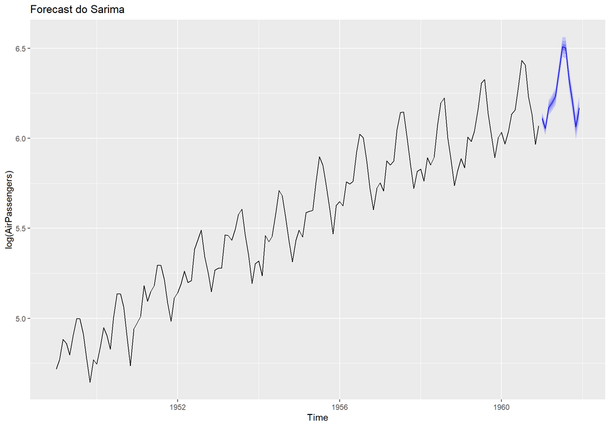

```r
#Grafico da previsao
autoplot(forecast.sarima)+
  ggtitle('Forecast do Sarima')
```

```r
accuracy(forecast.sarima)
```

```
#                        ME       RMSE        MAE        MPE      MAPE      MASE
# Training set 0.0005730622 0.03504883 0.02626034 0.01098898 0.4752815 0.2169522
#                    ACF1
# Training set 0.01443892
```

```r
#Avaliacao da Previsao
end(AirPassengers)
```

```
# [1] 1960   12
```

```r
fim <- c(1959,12)
amostra <- window(log(AirPassengers), end=fim)
observado <- window(log(AirPassengers), start=fim+c(0,1))

#Reestimacao do modelo
sarima2 <- auto.arima(amostra, max.p=0, max.d=1,
                      max.q=1, max.P=0, max.Q=1,  max.D=1,
                      seasonal = T, trace = TRUE)
```

```
#
#  ARIMA(0,1,1)(0,1,1)[12]                    : -441.0507
#  ARIMA(0,1,0)(0,1,0)[12]                    : -399.0167
#  ARIMA(0,1,1)(0,1,1)[12]                    : -441.0507
#  ARIMA(0,1,1)(0,1,0)[12]                    : -409.7503
#  ARIMA(0,1,0)(0,1,1)[12]                    : -430.1572
#
#  Best model: ARIMA(0,1,1)(0,1,1)[12]
```

```r
coeftest(sarima2)
```

```
#
# z test of coefficients:
#
#       Estimate Std. Error z value  Pr(>|z|)
# ma1  -0.348448   0.094280 -3.6959 0.0002191 ***
# sma1 -0.562260   0.077416 -7.2629  3.79e-13 ***
# ---
# Signif. codes:  0 '***' 0.001 '**' 0.01 '*' 0.05 '.' 0.1 ' ' 1
```

```r
summary(sarima2)
```

```
# Series: amostra
# ARIMA(0,1,1)(0,1,1)[12]
#
# Coefficients:
#           ma1     sma1
#       -0.3484  -0.5623
# s.e.   0.0943   0.0774
#
# sigma^2 = 0.001338:  log likelihood = 223.63
# AIC=-441.26   AICc=-441.05   BIC=-432.92
#
# Training set error measures:
#                      ME       RMSE        MAE        MPE      MAPE      MASE
# Training set 0.00104934 0.03443221 0.02590904 0.01899277 0.4738142 0.2113963
#                     ACF1
# Training set 0.004637637
```

```r
#previsao com o novo modelo
forecast.sarima2 <- forecast(sarima2, h=length(observado), level=20)$mean
forecast.sarima2
```

```
#           Jan      Feb      Mar      Apr      May      Jun      Jul      Aug
# 1960 6.038647 5.988763 6.145428 6.118993 6.159652 6.304666 6.433288 6.445958
#           Sep      Oct      Nov      Dec
# 1960 6.266719 6.136192 6.007899 6.114338
```

```r
observado
```

```
#           Jan      Feb      Mar      Apr      May      Jun      Jul      Aug
# 1960 6.033086 5.968708 6.037871 6.133398 6.156979 6.282267 6.432940 6.406880
#           Sep      Oct      Nov      Dec
# 1960 6.230481 6.133398 5.966147 6.068426
```

```r
accuracy(forecast.sarima2, observado)
```

```
#                   ME       RMSE        MAE        MPE      MAPE       ACF1
# Test set -0.02583023 0.04022576 0.02823101 -0.4227977 0.4619404 -0.2656265
#          Theil's U
# Test set 0.3858278
```